# HUDM 6122 Final Project

## Consistency

```r
# We use Cronbach's alpha , which is a measure of internal consistency, to see how closely related a set of variables are as a factor.
library(ltm)
f1 <- data[ , c("Price", "Resale_Value", "Fuel_Efficiency", "Maintenance", "Product_reviews")]
f2 <- data[ , c("Space_comfort", "Fuel_Type", "Safety", "Technology", "After_Sales_Service")]
f3 <- data[ , c("Color", "Exterior_Looks")]
f4 <- data[ , c("Testimonials", "Test_drive", "Product_reviews")]

fct <- data.frame(f1, f2, f3, f4)
cronbach.alpha(fct)
```

```
##
## Cronbach's alpha for the 'fct' data-set
##
## Items: 15
## Sample units: 90
## alpha: 0.653
```

```r
a1=psych::alpha(f1,check.keys = TRUE)$total[1]
a2=psych::alpha(f2,check.keys = TRUE)$total[1]
a3=psych::alpha(f3,check.keys = TRUE)$total[1]
a4=psych::alpha(f4,check.keys = TRUE)$total[1]
cbind(a1,a2,a3,a4)
```

```
##   raw_alpha raw_alpha raw_alpha raw_alpha
## 1 0.6644475 0.6049972 0.4967774  0.455053
```

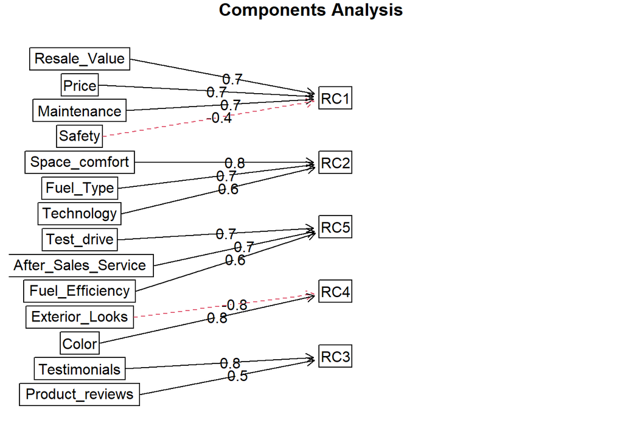

```r
#PCA grouping
#Check group:


fa.diagram(pc.fa)
```

```r
p1 = data[ , c("Price", "Resale_Value", "Maintenance", "Safety")]
p2 = data[ , c("Space_comfort","Technology","Fuel_Type")]
p5 = data[ , c("After_Sales_Service","Fuel_Efficiency","Test_drive")]
p4 = data[ , c("Color","Exterior_Looks")]
p3 = data[ , c("Testimonials","Product_reviews")]
b1=psych::alpha(p1,check.keys = TRUE)$total[1]
b2=psych::alpha(p2)$total[1]
b3=psych::alpha(p3)$total[1]
b4=psych::alpha(p4,check.keys = TRUE)$total[1]
b5=psych::alpha(p5)$total[1]
cbind(b1,b2,b3,b4,b5)
```

```
##   raw_alpha raw_alpha raw_alpha raw_alpha raw_alpha
## 1 0.5828464  0.561042 0.3852102 0.4967774 0.5311811
```

```r
pct <- data.frame(p1, p2, p3, p4,p5)
cronbach.alpha(pct)
```

```
##
## Cronbach's alpha for the 'pct' data-set
##
## Items: 14
## Sample units: 90
## alpha: 0.589
```

###### The overall consistency of MLE method by fa() is better than PCA method. The alpha for MLE method is 0.653 which is greater than the alpha for PCA method is 0.589. By looking at the group alpha value of MLE, we can see that the first two group’s alpha values are 0.66 and 0.60 which are more consistent than the other two (0.50 and 0.46).

## Conclusion

###### We first checked the factorability of our dataset found that the dataset is adequate for conducting a factor analysis. Then, we used three methods including parallel analysis, scree plot and eigenvalues to determine that we will use 5 factors in our factor analysis. However, for fa(), we tested that 4 factors are adequate with our analysis so we used 4 factors in fa(). To conduct factor analysis, we used three functions, principal, fa and factanal. We conclude that PCA have a better performance among all three analysis because the total variance for PCA method is greater than fa and factanal. We then checked the alpha value of each groups and overall on consistency, and from the output, we acknowledged that the overall consistency for the one with MLE method by fa() function with 4 factors is better than the one with method with 5 factors. The four groups are as following:

###### - Group1: “Price”, “Resale_Value”, “Fuel_Efficiency”, “Maintenance”, “Product_reviews”.

###### - Group2: “Space_comfort”, “Fuel_Type”, “Safety”, “Technology”, “After_Sales_Service”.

###### - Group3: “Color”, “Exterior_Looks”.

###### - Group4: “Testimonials”, “Test_drive”, “Product_reviews”.

###### This result makes sense in the real world that Group1 is symbolized with the preference on cost effectiveness, Group 2 is a measurement of reliability, Group 3 is a measure of appearances and Group 4 is a measure of marketing.